# Homework 11

Vaishnavi Maganti

2026-02-16

## Instructions

Answer the following questions and complete the exercises in RMarkdown. Please embed all of your code and push your final work to your repository. Your final lab report should be organized, clean, and run free from errors. Remember, you must remove the `#` for the included code chunks to run. Be sure to add your name to the author header above. For any included plots, make sure they are clearly labeled. You are free to use any plot type that you feel best communicates the results of your analysis.

Make sure to use the formatting conventions of RMarkdown to make your report neat and clean!

## Load the libraries

```r
library(tidyverse)
library(janitor)
```

```r
options(scipen = 999)
```

## Data

For this homework, we are going to use the [Gapminder](https://www.gapminder.org/data/) data on population (pop), GDP per capita (gdp), and life expectancy (lex). These data were downloaded and compiled using the `gapminder_compile.Rmd` script in the data folder.

Let’s focus our attention on data from the past 100 years, between 1925 and 2025.

```r
gapminder <- read_csv("data/gapminder.csv") %>%
  clean_names() %>%
  filter(between(year, 1925, 2025))
```

1. Use the function(s) of your choice to get an idea of the overall structure of the data, including its dimensions, column names, classes, etc.

```r
glimpse(gapminder)
```

```
## Rows: 19,695
## Columns: 5
## $ country <chr> "Afghanistan", "Afghanistan", "Afghanistan", "Afghanistan", "A…
## $ year    <dbl> 1925, 1926, 1927, 1928, 1929, 1930, 1931, 1932, 1933, 1934, 19…
## $ pop     <dbl> 8748779, 8289705, 7854721, 7442562, 7121951, 6888085, 6736411,…
## $ gdp     <dbl> 1113.793, 1127.866, 1142.117, 1156.548, 1171.161, 1185.959, 12…
## $ lex     <dbl> 38.87, 39.01, 39.16, 39.30, 39.44, 39.59, 39.73, 39.88, 40.02,…
```

```r
names(gapminder)
```

```
## [1] "country" "year"    "pop"     "gdp"     "lex"
```

2. How many countries are represented in this dataset?

```r
gapminder %>%
summarize(n_countries = n_distinct(country))
```

```
## # A tibble: 1 × 1
##   n_countries
##         <int>
## 1         195
```

3. Which five countries have had the largest absolute population growth between 1925-2025? Show this as a table.

```r
population_growth <- gapminder %>%
  filter(year %in% c(1925, 2025)) %>%
     mutate(year=factor(year)) %>%
    select(country, year, pop) %>%
pivot_wider(
  names_from = year,
  values_from = pop
) %>%
  mutate(abs_growth = `2025`-`1925`) %>%
  arrange(desc(abs_growth)) %>%
  slice_head(n=5)

population_growth
```

```
## # A tibble: 5 × 4
##   country      `1925`     `2025` abs_growth
##   <chr>         <dbl>      <dbl>      <dbl>
## 1 India     304406019 1463865525 1159459506
## 2 China     473741473 1416096094  942354621
## 3 Indonesia  49685263  285721236  236035973
## 4 Pakistan   22624808  255219554  232594746
## 5 USA       116193761  347275807  231082046
```

4. Make a plot that shows population growth over time for the top country you found in question #3.

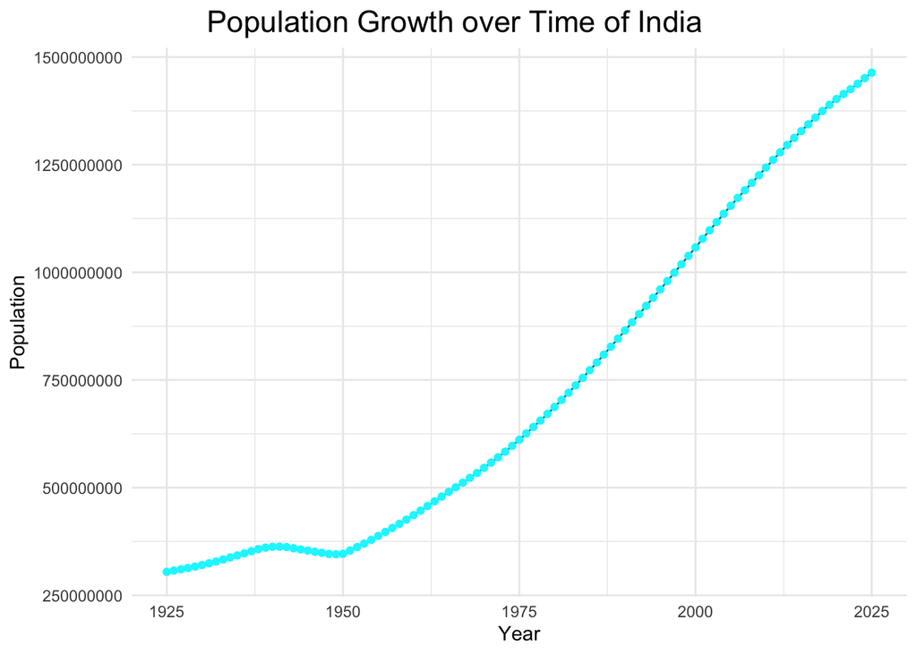

```r
gapminder %>%
  filter(country == population_growth$country[1]) %>%
  ggplot(aes(x=year, y = pop)) +
  geom_line(color="turquoise4") +
  geom_point(color="turquoise1") +
  labs(title = "Population Growth over Time of India",
       x="Year",
       y="Population") +
  theme_minimal() +
  theme(plot.title=element_text(size=rel(1.5), hjust = 0.27))
```

5. Has global life expectancy changed between 1925 and 2025? Show the min, median, mean, and max for all countries (combined) in the dataset.

```r
gapminder %>%
  filter(year %in% c(1925, 2025)) %>%
  group_by(year) %>%
  summarize(
    min_lex = min(lex, na.rm = T),
    median_lex = median(lex, na.rm = T),
    mean_lex = mean(lex, na.rm = T),
    max_lex = max(lex, na.rm = T),
  )
```

```
## # A tibble: 2 × 5
##    year min_lex median_lex mean_lex max_lex
##   <dbl>   <dbl>      <dbl>    <dbl>   <dbl>
## 1  1925    21.0       35.9     38.1    63.5
## 2  2025    52.8       74.8     73.9    85.6
```

Yes, it has increased.

6. Make a plot that shows the distribution of life expectancy for all countries in 1925 and 2025 (try using `geom_density`). What do you notice about the shift in life expectancy over time?

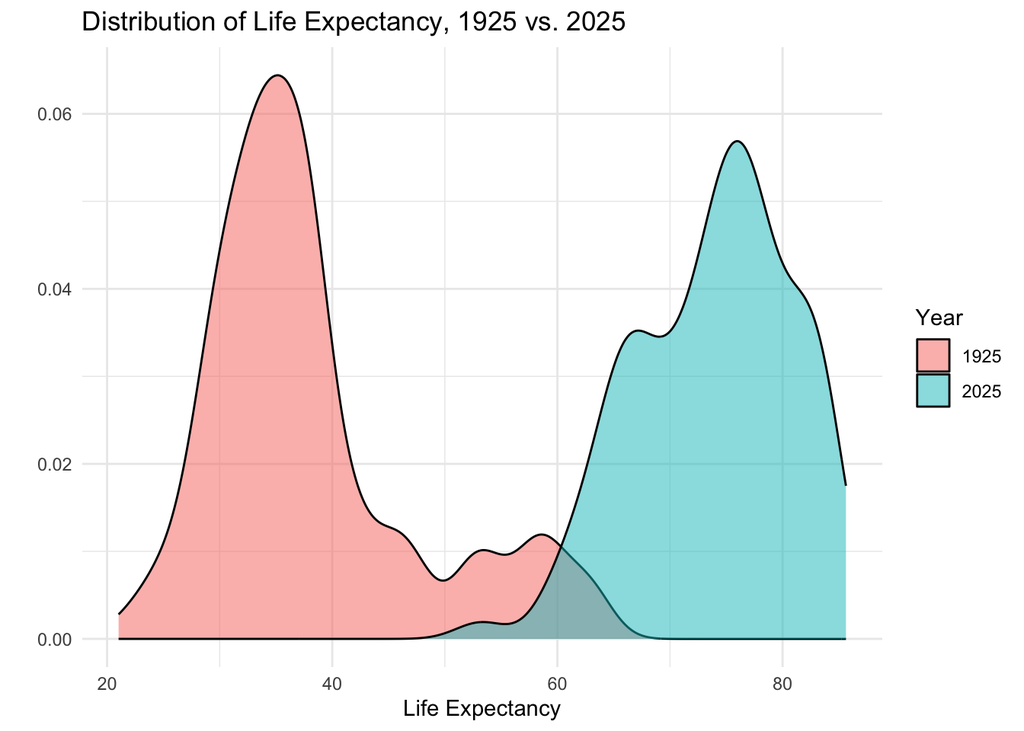

```r
gapminder %>%
  filter(year %in% c(1925, 2025)) %>%
  ggplot(aes(x=lex, fill = as.factor(year))) +
  geom_density(alpha = 0.5) +
  labs(title = "Distribution of Life Expectancy, 1925 vs. 2025",
       x= "Life Expectancy",
       fill = "Year",
       y="") +
  theme_minimal()
```

The minimum life expectancy is higher in 2025 as opposed to 1925, and the distribution is also more concentrated at older ages.

7. We are interested in the relationship between per capita GDP and life expectancy; i.e. does having more money help you live longer in 2025? Show this as a plot. (Suggestion! Remove Monaco as an extreme outlier.)

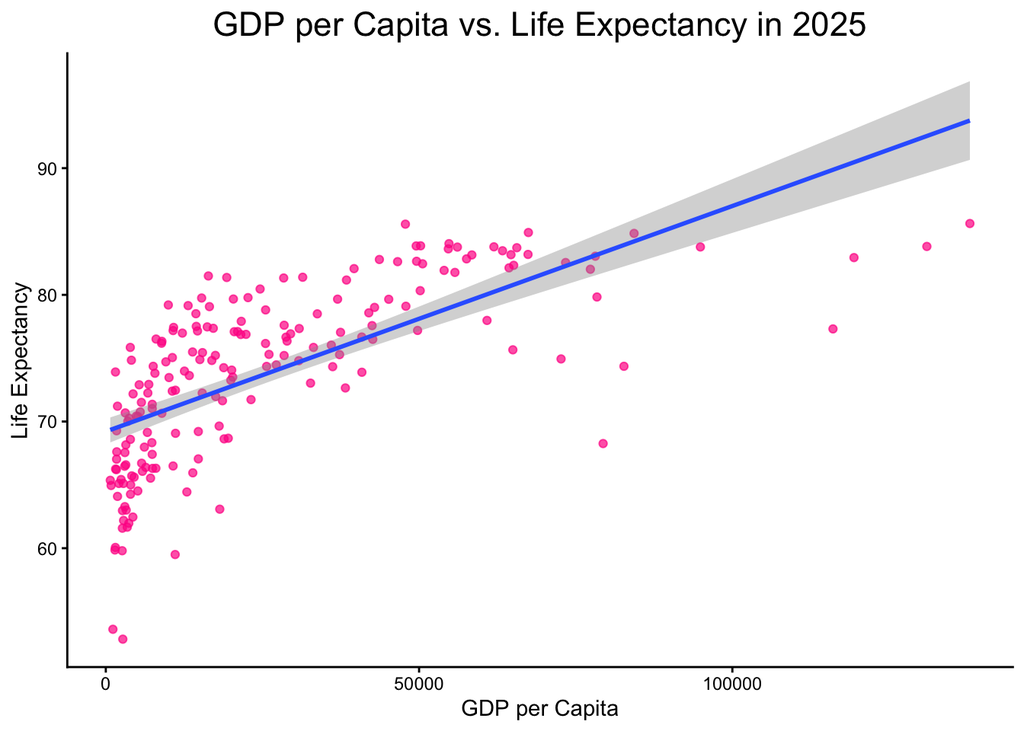

```r
gapminder %>%
  filter(year == 2025, country != "Monaco") %>%
  ggplot(aes(x=gdp, y=lex)) +
  geom_point(alpha = 0.7, color = "deeppink") +
  geom_smooth(method = "lm", se = T) +
  labs(title = "GDP per Capita vs. Life Expectancy in 2025",
       x="GDP per Capita",
       y= "Life Expectancy") +
  theme_classic() +
   theme(plot.title=element_text(size=rel(1.5), hjust = 0.5))
```

8. Which five countries have had the highest absolute GDP per capita growth over the past 50 years? Show this as a table. (Suggestion! Remove Monaco as an extreme outlier.)

```r
gdp_growth <- gapminder %>%
  filter(year %in% c(1975, 2025), country != "Monaco") %>%
  select(country, year, gdp) %>%
  pivot_wider(
    names_from = year,
    values_from = gdp
  ) %>%
  mutate(abs_growth = `2025` - `1975`) %>%
  arrange(desc(abs_growth)) %>%
  slice_head(n=5)

gdp_growth
```

```
## # A tibble: 5 × 4
##   country    `1975`  `2025` abs_growth
##   <chr>       <dbl>   <dbl>      <dbl>
## 1 Singapore  12896. 137906.    125010.
## 2 Ireland    14336. 119406.    105071.
## 3 Luxembourg 30950. 131038.    100088.
## 4 Guyana      5071.  79371.     74300.
## 5 Norway     25513.  94896.     69382.
```

9. How does per capita GDP growth compare between these same five countries over the past 50 years? Show this as a plot.

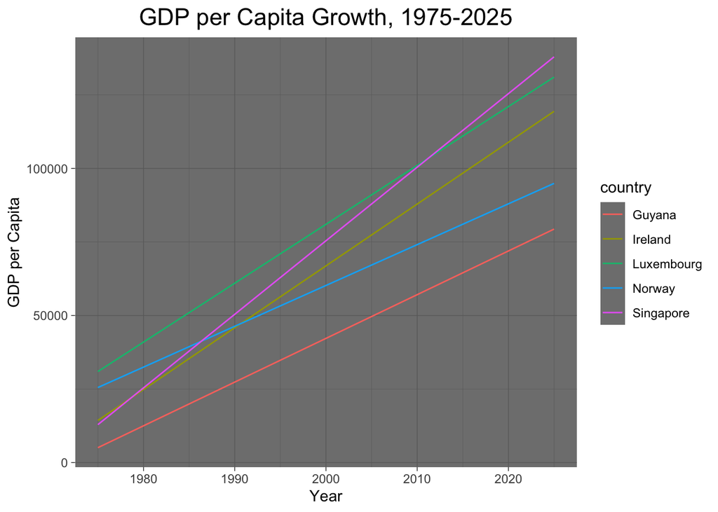

```r
gapminder %>%
  filter(country %in% gdp_growth$country,
         year %in% c(1975, 2025)) %>%
  ggplot(aes(x=year, y = gdp, color = country)) +
  geom_line() +
  labs(title = "GDP per Capita Growth, 1975-2025",
       x= "Year",
       y= "GDP per Capita") +
  theme_dark() +
  theme(plot.title=element_text(size=rel(1.5), hjust = 0.5))
```

10. Do one analysis of your choice that includes a table and plot as outputs.

Has life expectancy improved differently across the top 5 countries?

```r
country_life <- gapminder %>%
  filter(year %in% c(1925, 2025)) %>%
  select(country, year, lex) %>%
  pivot_wider(
    names_from = year,
    values_from = lex
  ) %>%
  mutate(abs_growth = `2025`-`1925`) %>%
  arrange(desc(abs_growth)) %>%
  slice_head(n=5)

country_life
```

```
## # A tibble: 5 × 4
##   country     `1925` `2025` abs_growth
##   <chr>        <dbl>  <dbl>      <dbl>
## 1 South Korea   29.3   83.6       54.4
## 2 Iran          25.4   79.1       53.7
## 3 North Korea   21.0   73.9       52.9
## 4 Bangladesh    23.5   76.3       52.8
## 5 Kuwait        30.9   82.6       51.8
```

Plot of Life Expectancy over Time for the Top Country

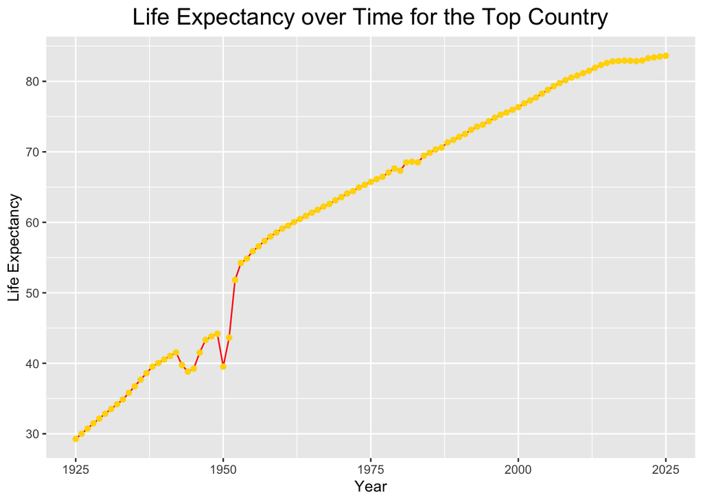

```r
gapminder %>%
  filter(country == country_life$country[1]) %>%
  ggplot(aes(x=year, y=lex)) +
  geom_line(color = "red") +
  geom_point(color = "gold") +
  labs(title = "Life Expectancy over Time for the Top Country",
       x="Year",
       y="Life Expectancy") +
  theme_grey() +
    theme(plot.title=element_text(size=rel(1.5), hjust = 0.5))
```

## Knit and Upload

Please knit your work as an .html file and upload to Canvas. Homework is due before the start of the next lab. No late work is accepted. Make sure to use the formatting conventions of RMarkdown to make your report neat and clean!